# Project 2 Classification Set

Jane Shen

# Data Cleaning

Link to the data : https://www.kaggle.com/aaronschlegel/austin-animal-center-shelter-intakes-and-outcomes

aac_outcome.csv is a dataset of animals reported in the Austin Animal Shelter.

These columns were removed because they are unnecessary :

- animal_id, date_of_birth, datetime, monthyear, name, outcome_subtype

```r
# Load data set
Animal <- read.csv("aac_outcomes.csv", stringsAsFactors=TRUE, header=TRUE)
df <- Animal

# Remove unwanted columns
drop <- c("animal_id","date_of_birth","datetime","monthyear","name","outcome_subtype", "color")
df <- df[,!(names(df) %in% drop)]

# Convert empty strings to NA to make cleaning easier
library(dplyr)
df <- mutate_all(df, list(~na_if(.,"")))

# Remove rows with sex_upon_outcome "Unknown"
df <- df[!df$sex_upon_outcome=="Unknown",]

# Remove rows with age_upon_outcome "NULL"
df <- df[!df$age_upon_outcome=="NULL",]

# Convert outcome_type to a binary column, either adopted or not
df$outcome_type <- ifelse(df$outcome_type=="Adoption", 1, 0)

# Convert age_upon_outcome to days instead of weeks/months/years
library(stringi)
convert_days <- function(str) {
  days <- as.integer(stri_extract_first_regex(str,"[0-9]+"))
  type <- stri_extract_first_regex(str,"[a-z]")
  if(type=="w"){
    days <- days * 7
  }
  if(type=="m"){
    days <- days * 30
  }
  if(type=="y"){
    days <- days * 365
  }
  return(days)
}

df$age_upon_outcome <- lapply(df$age_upon_outcome, convert_days)
df$age_upon_outcome <- as.numeric(df$age_upon_outcome)

# Broaden the levels with high variance
df$breed <- ifelse(is.na(stri_extract_first_regex(df$breed,"Mix")), 0, 1)

# Factor columns as needed
df$outcome_type <- as.factor(df$outcome_type)
df$breed <- as.factor(df$breed)

# Keep only complete observations
df <- df[complete.cases(df),]
```

# Data Exploration

```r
summary(df)
```

```
 age_upon_outcome    animal_type    breed     outcome_type      sex_upon_outcome
 Min.   :   0.0   Bird     :  146   0:11394   0:39695      Intact Female: 9367
 1st Qu.:  90.0   Cat      :27436   1:62462   1:34161      Intact Male  : 9788
 Median : 365.0   Dog      :45609                          Neutered Male:28699
 Mean   : 823.3   Livestock:    8                          NULL         :    1
 3rd Qu.:1095.0   Other    :  657                          Spayed Female:26001
 Max.   :9125.0                                            Unknown      :    0
```

```r
dim(df)
```

```
[1] 73856     5
```

```r
names(df)
```

```
[1] "age_upon_outcome" "animal_type"      "breed"            "outcome_type"     "sex_upon_outcome"
```

```r
str(df)
```

```
'data.frame':   73856 obs. of  5 variables:
 $ age_upon_outcome: num  14 365 365 3285 120 ...
 $ animal_type     : Factor w/ 5 levels "Bird","Cat","Dog",..: 2 3 3 3 3 2 2 2 3 3 ...
 $ breed           : Factor w/ 2 levels "0","1": 2 2 1 2 2 2 2 2 1 1 ...
 $ outcome_type    : Factor w/ 2 levels "0","1": 1 1 2 1 1 2 2 1 1 2 ...
 $ sex_upon_outcome: Factor w/ 6 levels "Intact Female",..: 2 5 3 3 2 1 5 5 3 3 ...
```

```r
head(df)
```

|  | age_upon_outcome | animal_type | breed | outcome_type | sex_upon_outcome |
| --- | --- | --- | --- | --- | --- |
| 1 | 14 | Cat | 1 | 0 | Intact Male |
| 2 | 365 | Dog | 1 | 0 | Spayed Female |
| 3 | 365 | Dog | 0 | 1 | Neutered Male |
| 4 | 3285 | Dog | 1 | 0 | Neutered Male |
| 6 | 120 | Dog | 1 | 0 | Intact Male |
| 7 | 30 | Cat | 1 | 1 | Intact Female |

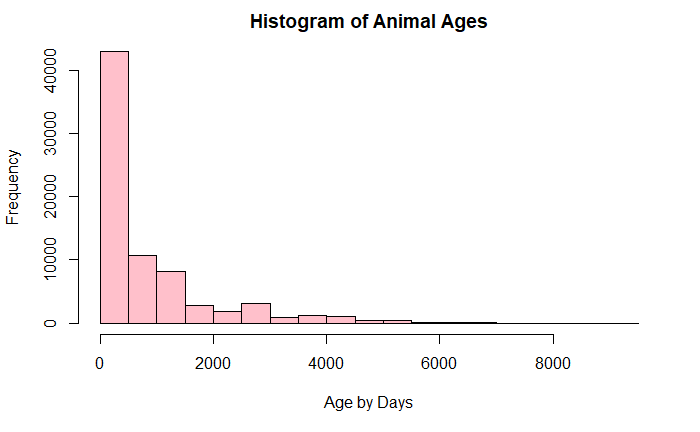

```r
hist(df$age_upon_outcome, col="pink", main="Histogram of Animal Ages", xlab="Age by Days")
```

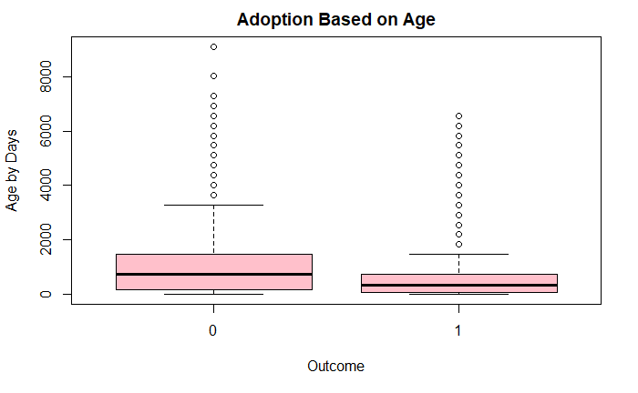

```r
plot(df$outcome_type, df$age_upon_outcome, xlab="Outcome", ylab="Age by Days", main="Adoption Based on Age", col="pink", pch=1)
```

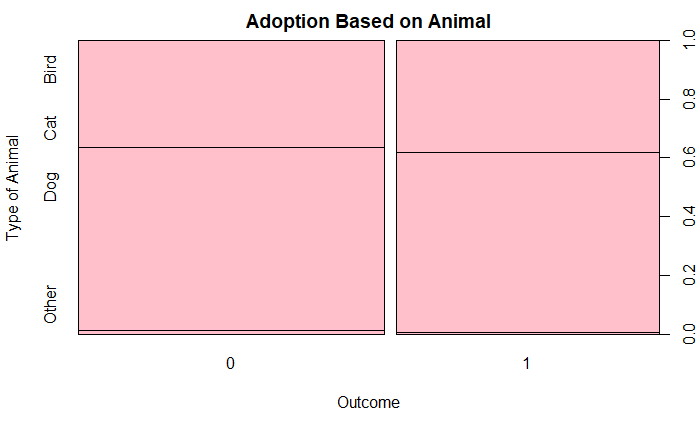

```r
plot(df$outcome_type, df$animal_type, xlab="Outcome", ylab="Type of Animal", main="Adoption Based on Animal", col="pink", pch=1)
```

# Modeling

```r
# Divide into train and test sets
set.seed(1234)
i <- sample(1:nrow(df), nrow(df) * 0.75, replace=FALSE)
train <- df[i,]
test <- df[-i,]
```

# Logistic Regression

Prediction accuracy was decent, the middle of the 3 models. After changing breed from specific breeds to mixed and non mixed, it appears to no longer be a favorable predictors. Livestock animal type is also a poor predictor, but that is to be expected because there are likely not many livestock in the data set.

```r
# Build the Model
glm1 <- glm(outcome_type~., data=train, family=binomial)
summary(glm1)
```

```
Call:
glm(formula = outcome_type ~ ., family = binomial, data = train)

Deviance Residuals:
    Min       1Q   Median       3Q      Max
-1.9519  -0.9385  -0.2941   0.8892   3.5189

Coefficients:
                                Estimate Std. Error z value Pr(>|z|)
(Intercept)                    2.843e-01  2.015e-01   1.411    0.158
age_upon_outcome              -6.009e-04  1.087e-05 -55.278  < 2e-16 ***
animal_typeCat                -2.386e+00  1.976e-01 -12.078  < 2e-16 ***
animal_typeDog                -2.728e+00  1.978e-01 -13.791  < 2e-16 ***
animal_typeLivestock          -1.199e+00  1.147e+00  -1.046    0.296
animal_typeOther              -1.874e+00  2.357e-01  -7.949 1.88e-15 ***
breed1                         1.881e-02  2.808e-02   0.670    0.503
sex_upon_outcomeIntact Male   -2.552e-01  6.517e-02  -3.916 9.01e-05 ***
sex_upon_outcomeNeutered Male  3.173e+00  4.759e-02  66.675  < 2e-16 ***
sex_upon_outcomeNULL          -5.587e+00  7.246e+01  -0.077    0.939
sex_upon_outcomeSpayed Female  3.368e+00  4.784e-02  70.409  < 2e-16 ***
---
Signif. codes:  0 ‘***’ 0.001 ‘**’ 0.01 ‘*’ 0.05 ‘.’ 0.1 ‘ ’ 1

(Dispersion parameter for binomial family taken to be 1)

    Null deviance: 76480  on 55391  degrees of freedom
Residual deviance: 58271  on 55381  degrees of freedom
AIC: 58293

Number of Fisher Scoring iterations: 8
```

```r
# Evaluate on test data
probs_glm <- predict(glm1, newdata=test, type="response")
pred_glm <- ifelse(probs_glm>0.5, 1, 0)
acc_glm <- mean(pred_glm==test$outcome_type)

print(paste("glm1 accuracy: ", acc_glm))
```

```
[1] "glm1 accuracy:  0.732073223570191"
```

# Naive Bayes

Prediction accuracy was the poorest of all 3 models, likely because Naive Bayes is meant for smaller data sets, and this data set includes more than 70,000 observations.

```r
# Build the model
library(e1071)
nb1 <- naiveBayes(outcome_type~., data=train)
summary(nb1)
```

```
          Length Class  Mode
apriori   2      table  numeric
tables    4      -none- list
levels    2      -none- character
isnumeric 4      -none- logical
call      4      -none- call
```

```r
# Evaluate on test data
pred_nb <- predict(nb1, newdata=test, type="class")
acc_nb <- mean(pred_nb==test$outcome_type)

print(paste("nb1 accuracy: ", acc_nb))
```

```
[1] "nb1 accuracy:  0.724761698440208"
```

# Decision Tree

Prediction accuracy was the highest of all 3 models, and no pruning was necessary either as the default tree was well balanced and simple.

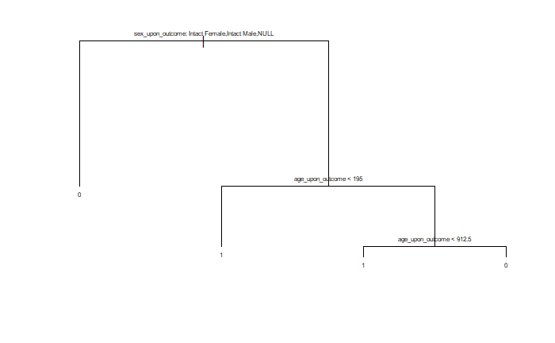

```r
# Build the model
library(tree)
tree1 <- tree(outcome_type~., data=train)
plot(tree1)
text(tree1, cex=0.5, pretty=0)
```

```r
# Evaluate on test data
pred_tree <- predict(tree1, newdata=test, type="class")
acc_tree <- mean(pred_tree == test$outcome_type)

print(paste("tree1 accuracy: ", acc_tree))
```

```
[1] "tree1 accuracy:  0.742201039861352"
```

# Ensemble Method

```r
# Build the model
library(xgboost)
bst1 <- xgboost(data=data.matrix(train[,-4], rownames.force=NA), label=data.matrix(train[,4], rownames.force=NA), nround=100, objective="binary:logistic")
summary(bst1)
```

```
               Length Class              Mode
handle              1 xgb.Booster.handle externalptr
raw            188573 -none-             raw
niter               1 -none-             numeric
evaluation_log      2 data.table         list
call               14 -none-             call
params              2 -none-             list
callbacks           2 -none-             list
feature_names       4 -none-             character
nfeatures           1 -none-             numeric
```

```r
# Evaluate on test set
prob_bst <- predict(bst1, data.matrix(test[,-4], rownames.force=NA))
pred_bst <- ifelse(prob_bst>0.5, 1, 0)

acc_bst <- mean(pred_bst==test$outcome_type)

print(paste("bst1 accuracy: ", acc_bst))
```

```
[1] "bst1 accuracy:  0.746046360485269"
```

# Comparison and Analysis

Best to worst accuracy

- XGBoost Accuracy : 0.7460
- Decision Tree Accuracy : 0.7422
- Logistic Regression Accuracy : 0.7321
- Naive Bayes Accuracy : 0.7248

Unsurprisingly, XGBoost won in accuracy, even though it is slight. This is expected because XGBoost is known to be better than other models in both accuracy, speed, and interpretability.

The decision tree model had the best accuracy of all 3 models, likely because logistic regression assumes a linear data set, and naive bayes does not work well with large data sets. The tree was also very simple and balanced, which is favorable for its prediction accuracy.